# SQL Showcase

# Views

## View - Outstanding Orders

A view for seeing the outstanding orders, and attaching related useful information from other tables such as ‘Products’, ‘Customers’, ‘OrderDetails’ and ‘Shippers’.

### [VIEW | LEFT JOIN]

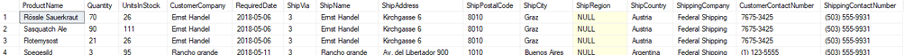

```sql
CREATE VIEW OutstandingOrders AS
    SELECT --TOP(99) PERCENT --Pre-Ordering Option
        Products.ProductName,
        OrderDetails.Quantity,
        Products.UnitsInStock,
        Customers.CompanyName CustomerCompany,
        Orders.RequiredDate,
        Orders.ShipVia,
        Orders.ShipName,
        Orders.ShipAddress,
        Orders.ShipPostalCode,
        Orders.ShipCity,
        Orders.ShipRegion,
        Orders.ShipCountry,
        Shippers.CompanyName ShippingCompany,
        Customers.Phone CustomerContactNumber,
        Shippers.Phone ShippingContactNumber
    FROM
        Orders
        LEFT JOIN Customers
            ON Orders.CustomerID = Customers.CustomerID
        LEFT JOIN OrderDetails
            ON Orders.OrderID = OrderDetails.OrderID
        LEFT JOIN Products
            ON OrderDetails.ProductID = Products.ProductID
        LEFT JOIN Shippers
            ON Orders.ShipVia = Shippers.ShipperID
    WHERE
        Orders.ShippedDate IS NULL
    --ORDER BY RequiredDate, CustomerCompany DESC --Pre-Ordering Option
GO

SELECT * FROM OutstandingOrders
ORDER BY RequiredDate, CustomerCompany
```

## View - Expired Batches

A view for seeing which batches are past their expiry date using an inner join to also see the associated product name.

### [VIEW | INNER JOIN]

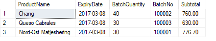

```sql
CREATE VIEW ExpiredBatches AS

    SELECT
        Products.ProductName,
        ProductBatches.ExpiryDate,
        ProductBatches.BatchQuantity,
        ProductBatches.BatchNo,
        (ProductBatches.BatchQuantity * Products.UnitPrice) Subtotal
    FROM
        ProductBatches
            INNER JOIN Products
                ON Products.ProductID = ProductBatches.ProductID
    WHERE ExpiryDate <= GETDATE()
            AND BatchQuantity > 0
GO

SELECT * FROM ExpiredBatches
```

# Functions

## Function - Stock Check

A scalar function that allows for a product name to be entered and the total number of units in stock of that item to be returned.

### [SCALAR FUNCTION]

```sql
CREATE FUNCTION InventoryCheck(@Product nvarchar(50))
RETURNS int AS
BEGIN

    DECLARE @TotalStock int

    SELECT @TotalStock = SUM(UnitsInStock)
    FROM Products
    WHERE ProductName LIKE CONCAT('%', @Product, '%')

    RETURN @TotalStock

END
GO

SELECT dbo.InventoryCheck('Chai')
```

## Function - Batches Nearing Expiry

A tabular function that allows for a list of products to be entered and a table of the batches containing those items to be returned in order of nearest to farthest expiry date.

### [TABLE FUNCTION | SUBQUERY]

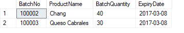

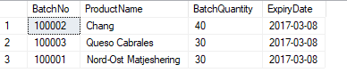

```sql
CREATE FUNCTION ExpiringBatches(@Products nvarchar(500))
RETURNS @Results TABLE
    (
        BatchNo int,
        ProductName nvarchar(50),
        BatchQuantity int,
        ExpiryDate date
    )
AS
BEGIN

DECLARE @LookupList TABLE(LookupItem nvarchar(50))

INSERT INTO @LookupList SELECT p.value FROM STRING_SPLIT(@Products, ',') p

INSERT INTO @Results
SELECT
    ProductBatches.BatchNo,
    Products.ProductName,
    ProductBatches.BatchQuantity,
    ProductBatches.ExpiryDate
FROM ProductBatches
            INNER JOIN Products
                ON ProductBatches.ProductID = Products.ProductID
WHERE
    EXISTS( SELECT * FROM @LookupList LL WHERE ProductName like '%'+ TRIM(LL.LookupItem) +'%' )
ORDER BY ExpiryDate
RETURN
END
GO

SELECT * FROM ExpiringBatches('Chang, Queso Cabrales')
SELECT * FROM ExpiringBatches('')
```

## Function - Sales Performance

A function that uses a common table expression (CTE) to return aggregated monthly sales data for each employee between given date parameters, and using case statements can be optionally ordered depending on another parameter.

### [TABLE FUNCTION | CTE | CASE WHEN | GROUP BY | ORDER BY | LEFT JOIN | AGGREGATED FUNCTIONS]

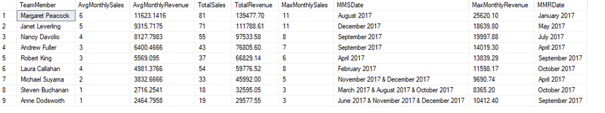

```sql
CREATE FUNCTION SalesPerformanceMonthly(@StartDate date, @EndDate date, @OrderBy nvarchar(50) = NULL)
RETURNS TABLE AS
RETURN(

-- Set up CTE with aggregated sales data for each employee and each month between the start and end date parameters
WITH CTE_MonthlySales AS(
            SELECT
                CONCAT(Employees.FirstName, ' ', Employees.LastName) TeamMember,
                COUNT(DISTINCT(Orders.OrderID)) MonthlyTotalSales,
                SUM(OrderDetails.Quantity * OrderDetails.UnitPrice) MonthlyTotalRevenue,
                CAST(DATEADD(MONTH, DATEDIFF(MONTH, 0, Orders.OrderDate), 0) as date) SalesMonth
            FROM
                Employees
                    INNER JOIN Orders
                        ON Employees.EmployeeID = Orders.EmployeeID
                    INNER JOIN OrderDetails
                        ON Orders.OrderID = OrderDetails.OrderID
            WHERE
                Orders.OrderDate >= @StartDate
                AND Orders.OrderDate <= @EndDate
            GROUP BY
                CONCAT(Employees.FirstName, ' ', Employees.LastName), DATEADD(MONTH, DATEDIFF(MONTH, 0, Orders.OrderDate), 0)
)

        -- 'Top 99 Percent' is to help the order by function;
        -- AvgMonthlySales isn't aggregated using the AVG function so as to account for months with 0 sales
        SELECT TOP 99.99 PERCENT
            a.TeamMember TeamMember,
            a.TotalSales / DATEDIFF(MONTH, @StartDate, @EndDate) AvgMonthlySales,
            a.TotalRevenue / DATEDIFF(MONTH, @StartDate, @EndDate) AvgMonthlyRevenue,
            a.TotalSales TotalSales,
            a.TotalRevenue TotalRevenue,
            a.MaxMonthlySales MaxMonthlySales,
            string_agg(b.MMSDate, ' & ') MMSDate,
            a.MaxMonthlyRevenue MaxMonthlyRevenue,
            c.MMRDate MMRDate
        FROM
            (
                SELECT
                    TeamMember,
                    SUM(MonthlyTotalSales) TotalSales,
                    SUM(MonthlyTotalRevenue) TotalRevenue,
                    MAX(MonthlyTotalSales) MaxMonthlySales,
                    MAX(MonthlyTotalRevenue) MaxMonthlyRevenue
                FROM
                    CTE_MonthlySales
                GROUP BY
                    TeamMember
            ) a
            -- Joins allow the finding of the month in which the employee had their highest sales/revenue
            LEFT JOIN
            (
                SELECT
                    TeamMember,
                    CONCAT(DATENAME(MONTH, SalesMonth), ' ', DATEPART(Year, SalesMonth)) MMSDate,
                    MonthlyTotalSales
                FROM
                    CTE_MonthlySales
            ) b
                ON a.TeamMember = b.TeamMember
                AND a.MaxMonthlySales = b.MonthlyTotalSales
            LEFT JOIN
            (
                SELECT
                    TeamMember,
                    CONCAT(DATENAME(MONTH, SalesMonth), ' ', DATEPART(Year, SalesMonth)) MMRDate,
                    MonthlyTotalRevenue
                FROM
                    CTE_MonthlySales
            ) c
                ON a.TeamMember = c.TeamMember
                AND a.MaxMonthlyRevenue = c.MonthlyTotalRevenue
        GROUP BY
            a.TeamMember,
            a.TotalSales,
            a.TotalRevenue,
            a.MaxMonthlySales,
            a.MaxMonthlyRevenue,
            c.MMRDate

        -- Using seperate case statements for each data type handled to overcome a SQL bug
        ORDER BY
            CASE
                WHEN @OrderBy LIKE '%av%' AND @OrderBy LIKE '%sal%' THEN a.TotalSales / DATEDIFF(MONTH, @StartDate, @EndDate)
                WHEN @OrderBy LIKE '%tot%' AND @OrderBy LIKE '%sal%' THEN a.TotalSales
                WHEN @OrderBy LIKE '%max%' AND @OrderBy LIKE '%sal%' THEN a.MaxMonthlySales
            END DESC,
            CASE
                WHEN @OrderBy LIKE '%av%' AND @OrderBy LIKE '%rev%' THEN a.TotalRevenue / DATEDIFF(MONTH, @StartDate, @EndDate)
                WHEN @OrderBy LIKE '%tot%' AND @OrderBy LIKE '%rev%' THEN a.TotalRevenue
                WHEN @OrderBy LIKE '%max%' AND @OrderBy LIKE '%rev%' THEN a.MaxMonthlyRevenue
            END DESC

)
GO

SELECT * FROM SalesPerformanceMonthly('01/01/2017', '01/01/2018', 'average revenue')
```

# Procedures

## Procedure - Purchase Received

An ACID procedure by which the arrival of a purchase can be logged just by entering the product name, quantity and expiry date of the delivery.

### [PROCEDURE | TRANSACTION | TRY CATCH | SUB-QUERY | LEFT JOIN]

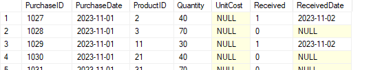

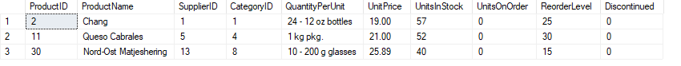

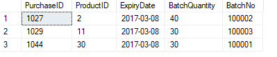

```sql
CREATE PROCEDURE PurchaseReceived

    @ProductName nvarchar(100),
    @Quantity int,
    @ExpiryDate date

AS
BEGIN

    BEGIN TRANSACTION;
    SAVE TRANSACTION ChkPnt;

    BEGIN TRY
    UPDATE Purchases
    SET
        Purchases.Received = 1,
        Purchases.ReceivedDate = GETDATE()
    FROM
        Purchases
            LEFT JOIN Products
                ON Purchases.ProductID = Products.ProductID
    WHERE
        Products.ProductName LIKE '%' + @ProductName + '%'
            AND Purchases.Quantity = @Quantity
            AND Purchases.Received = 0
            AND Purchases.ReceivedDate IS NULL
            AND Purchases.PurchaseID =
                (
                    SELECT TOP(1) Purchases.PurchaseID
                    FROM Purchases
                        LEFT JOIN Products
                            ON Purchases.ProductID = Products.ProductID
                    WHERE Products.ProductName LIKE '%' + @ProductName + '%'
                        AND Purchases.Quantity = @Quantity
                        AND Purchases.Received = 0
                        AND Purchases.ReceivedDate IS NULL
                    ORDER BY PurchaseDate
                )

    UPDATE Products
    SET
        Products.UnitsInStock = Products.UnitsInStock + Purchases.Quantity,
        Products.UnitsOnOrder = Products.UnitsOnOrder - Purchases.Quantity
    FROM
        Products
            LEFT JOIN Purchases
                ON Products.ProductID = Purchases.ProductID
    WHERE
        Products.ProductName LIKE '%' + @ProductName + '%'
            AND Purchases.Quantity = @Quantity
            AND Purchases.Received = 1
            AND Purchases.ReceivedDate = CAST(GETDATE() AS date)
            AND Purchases.PurchaseID =
                (
                    SELECT TOP(1) Purchases.PurchaseID
                    FROM Purchases
                        LEFT JOIN Products
                            ON Purchases.ProductID = Products.ProductID
                    WHERE Products.ProductName LIKE '%' + @ProductName + '%'
                        AND Purchases.Quantity = @Quantity
                        AND Purchases.Received = 1
                        AND Purchases.ReceivedDate = CAST(GETDATE() AS date)
                    ORDER BY PurchaseDate
                )

    INSERT INTO ProductBatches
        SELECT
            Pur.PurchaseID,
            Pro.ProductID,
            @ExpiryDate,
            @Quantity
        FROM Purchases Pur
            LEFT JOIN Products Pro
                ON Pur.ProductID = Pro.ProductID
        WHERE Pro.ProductName LIKE '%' + @ProductName + '%'
            AND Pur.Quantity = @Quantity
            AND Pur.Received = 1
            AND Pur.ReceivedDate = CAST(GETDATE() AS date)
        ORDER BY PurchaseDate

    COMMIT TRANSACTION
    END TRY
    BEGIN CATCH
        IF @@TRANCOUNT > 0
        BEGIN
            ROLLBACK TRANSACTION ChkPnt
            SELECT 'Failed'
        END
    END CATCH
END
GO


exec PurchaseReceived 'Matjeshering', 30, '2017-03-08'
exec PurchaseReceived 'Chang', 40, '2017-03-08'
exec PurchaseReceived 'Queso Cabrales', 30, '2017-03-08'
```

## Procedure - Restock Check

A procedure that uses temporary tables to check for products whose stock have fallen bellow the ‘ReorderLevel’ and automatically fetches and sets information necessary for re-ordering the items.

### [PROCEDURE | TEMPORARY TABLE | TRANSACTION | TRY CATCH | IF | ALIASING | INNER & LEFT JOINS]

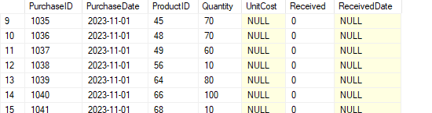

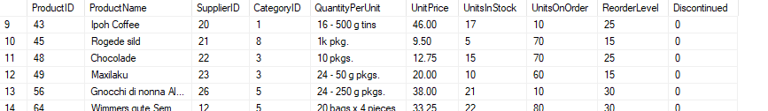

```sql
CREATE PROCEDURE AutoRestock
AS
BEGIN

    BEGIN TRANSACTION;
    SAVE TRANSACTION ChkPnt;

    BEGIN TRY
    DROP TABLE IF EXISTS #RestockNeeded
    CREATE TABLE #RestockNeeded
    (
        PurchaseDate date,
        ProductID int,
        Quantity int
    )

    INSERT INTO #RestockNeeded(PurchaseDate, ProductID, Quantity)
    SELECT
        GETDATE(),
        ProductID,
        2 * ReorderLevel
    FROM Products
    WHERE (UnitsInStock + UnitsOnOrder) <= ReorderLevel
        AND Discontinued = 0


    INSERT INTO Purchases (PurchaseDate, ProductID, Quantity, Received)
    SELECT
        PurchaseDate,
        ProductID,
        Quantity,
        0
    FROM #RestockNeeded

    UPDATE Products
    SET
        UnitsOnOrder = UnitsOnOrder + R.Quantity
    FROM
        Products P
            INNER JOIN #RestockNeeded R
                ON P.ProductID = R.ProductID

    SELECT
        P.ProductName,
        R.Quantity,
        S.CompanyName,
        S.ContactTitle,
        S.ContactName,
        S.Phone,
        S.Fax,
        S.HomePage

    FROM #RestockNeeded R
    LEFT JOIN Products P
        ON R.ProductID = P.ProductID
    LEFT JOIN Suppliers S
        ON P.SupplierID = S.SupplierID

    COMMIT TRANSACTION
    END TRY
    BEGIN CATCH
        IF @@TRANCOUNT > 0
        BEGIN
            ROLLBACK TRANSACTION ChkPnt
            SELECT 'Failed'
        END
    END CATCH
END
Go

exec AutoRestock
```

# Full Queries Documentation

```sql
-- Initial Data Review

SELECT *
FROM Categories
-- Looks good.


SELECT *
FROM CustomerCustomerDemo
-- Empty table, many-many relationship link.


SELECT *
FROM CustomerDemographics
-- Empty table, should contain demographic groupings of the customer base, CHECK DATA IMPORTED CORRECTLY.
-- !Data import checked - correctly imported.!


SELECT *
FROM Customers
-- 'Region' non-standardised and missing data - should be fine as postal code will suffice.
-- 'PostalCode' Missing data for HUNGO.
-- 'Fax' missing data; acceptable, some companies may not still use fax.
-- Includes sensitive data, requires appropriate protection and handling.


SELECT *
FROM Employees
-- 'BirthDate' and 'HireDate' are stored as datetimes when just date would do.
-- 'Region' missing data.
-- Includes sensitive data, requires appropriate protection and handling.
-- Add monthly salary field.
-- Add holiday leave used field.
-- Add holiday leave total field.
-- Possible split into several tables (Office, HR, etc.).

SELECT *
FROM EmployeeTerritories
-- Looks good.


SELECT *
FROM [Order Details]
-- Remove space from 'Order Details' to conform to the rest of the database's naming convention.
-- Add a batches field


SELECT *
FROM Orders
-- 'OrderDate', 'RequiredDate' and 'ShippedDate' are datetimes, whereas dates would be cleaner.
-- 'ShippedDate' has missing values, likely to be from not having shipped yet but check to be sure.
-- 'Freight' should be renamed to 'FreightRate' so as to be more clear that it is the cost of shipping.


SELECT *
FROM Products
-- Add a purchase table, (PurchaseID, PurchaseDate, Product_ID, Quantity, UnitPrice, Sub-total, ShippingMethod, Received, ReceivedDate).
-- Add a batch table, (BatchID, PurchaseID, ProductID, ExpiryDate, UnitsRemaining).


SELECT *
FROM Region
-- Looks good.


SELECT *
FROM Shippers
-- Looks good.


SELECT *
FROM Suppliers
-- 'Fax' and 'HomePage' missing data; acceptable, some companies may not use fax / website.

SELECT *
FROM Territories


-- Add a General Ledger View
-- Add a Sales Performance View
-- Add an Oldest Batch Function




-- Clean Data

-- Customers Table
-- 'PostalCode' Missing data for HUNGO.
SELECT *
FROM Customers
WHERE CustomerID = 'HUNGO'

Update Customers
SET PostalCode = 'T45 HE16'
WHERE CustomerID = 'HUNGO'

SELECT *
FROM Customers
WHERE PostalCode is NULL
-- Cleaned

-- Includes sensitive data, requires appropriate protection and handling.
SELECT *
FROM Customers
-- 'ContactName', 'Phone' and 'Fax' are/may be PII (personally identifiable information) and should be protected.
-- For the sake of this showcase masking the data should suffice.

-- Split the first and last names.
ALTER TABLE Customers
ADD  ContactFirstName nvarchar(20), ContactLastName nvarchar(20)

Update Customers
SET ContactFirstName = TRIM(SUBSTRING(ContactName, 1, CHARINDEX(' ', ContactName)))
GO

Update Customers
SET ContactLastName = TRIM(SUBSTRING(ContactName, CHARINDEX(' ', ContactName), LEN(ContactName)))

ALTER TABLE Customers
DROP COLUMN ContactName

-- Mask sensitive information.
ALTER TABLE Customers
ALTER COLUMN ContactFirstName ADD MASKED WITH (FUNCTION = 'partial(1, "****", 0)')

ALTER TABLE Customers
ALTER COLUMN Phone  ADD MASKED WITH (FUNCTION = 'partial(0, "####", 4)')

ALTER TABLE Customers
ALTER COLUMN Fax ADD MASKED WITH (FUNCTION = 'partial(0, "####", 4)')

-- Check masking.
CREATE USER Tester WITHOUT LOGIN
GRANT SELECT ON SCHEMA::dbo to Tester

EXECUTE as USER = 'Tester'
SELECT *
FROM Customers

REVERT
-- Cleaned


-- Employees Table
-- 'BirthDate' and 'HireDate' are stored as datetimes when just date would do.
ALTER TABLE Employees
DROP CONSTRAINT CK_BirthDate

ALTER TABLE Employees
ALTER COLUMN BirthDate DATE

ALTER TABLE Employees
ALTER COLUMN HireDate DATE

ALTER TABLE Employees
ADD CONSTRAINT "CK_Birthdate" CHECK (BirthDate < getdate())
-- Cleaned


-- 'Region' missing data.
UPDATE Employees
SET Region = 'London'
WHERE City = 'London'
-- Cleaned

-- Includes sensitive data, requires appropriate protection and handling.
ALTER TABLE Employees
ALTER COLUMN FirstName ADD MASKED WITH (FUNCTION = 'partial(1, "****", 0)')

ALTER TABLE Employees
ALTER COLUMN BirthDate ADD MASKED WITH (FUNCTION = 'default()')

ALTER TABLE Employees
ALTER COLUMN HireDate ADD MASKED WITH (FUNCTION = 'default()')

ALTER TABLE Employees
ALTER COLUMN [Address] ADD MASKED WITH (FUNCTION = 'default()')

ALTER TABLE Employees
ALTER COLUMN PostalCode ADD MASKED WITH (FUNCTION = 'default()')

ALTER TABLE Employees
ALTER COLUMN HomePhone ADD MASKED WITH (FUNCTION = 'partial(0, "####", 4)')

ALTER TABLE Employees
ALTER COLUMN Photo ADD MASKED WITH (FUNCTION = 'default()')

ALTER TABLE Employees
ALTER COLUMN Notes ADD MASKED WITH (FUNCTION = 'default()')

ALTER TABLE Employees
ALTER COLUMN PhotoPath ADD MASKED WITH (FUNCTION = 'default()')

EXECUTE as USER = 'Tester'
SELECT *
FROM Employees

REVERT
-- Cleaned


-- Order Details Table
-- Remove space from 'Order Details' to conform to the rest of the database's naming convention.
exec sp_rename 'Order Details', 'OrderDetails'
-- Cleaned


-- Orders Table
-- 'OrderDate', 'RequiredDate' and 'ShippedDate' are datetimes, whereas dates would be cleaner.
DROP INDEX Orders.OrderDate

ALTER TABLE Orders
ALTER COLUMN OrderDate DATE

ALTER TABLE Orders
ALTER COLUMN RequiredDate DATE

DROP INDEX Orders.ShippedDate

ALTER TABLE Orders
ALTER COLUMN ShippedDate DATE

CREATE INDEX OrderDate
ON Orders (OrderDate)

CREATE INDEX ShippedDate
ON Orders (ShippedDate)
-- Cleaned

-- 'ShippedDate' has missing values, likely to be from not having shipped yet but check to be sure.
SELECT OrderID, OrderDate, RequiredDate, ShippedDate
FROM Orders
ORDER BY 3, 2, 4
-- Suspect orders haven't been shipped yet.

-- 'Freight' should be renamed to 'FreightRate' so as to be more clear that it is the cost of shipping.
EXEC sp_RENAME 'Orders.Freight' , 'FreightRate', 'COLUMN'
-- Cleaned



--Add Fields

-- Employees Table
-- Add monthly salary field.
ALTER TABLE Employees
ADD MonthlySalary money NOT NULL DEFAULT 0
-- Populate (Random data for the sake of showcase)
UPDATE Employees
SET MonthlySalary = (ROUND(abs(checksum(NewId())) / 100000 + 20000, -2))
```

```sql
-- Add holiday leave used field.
ALTER TABLE Employees
ADD HolidayLeaveUsed int NULL
UPDATE Employees
SET HolidayLeaveUsed = (ROUND(abs(checksum(NewId())) / 100000000, 0))

-- Add holiday leave total field.
ALTER TABLE Employees
ADD HolidayLeaveTotal int NULL
UPDATE Employees
SET HolidayLeaveTotal = 21



-- Create Tables


-- Add a purchase table, (PurchaseID, PurchaseDate, ProductID, Quantity, UnitPrice, Received, ReceivedDate).
CREATE TABLE Purchases
(
    PurchaseID int IDENTITY (1001, 1) PRIMARY KEY NOT NULL,
    PurchaseDate date NOT NULL,
    ProductID int NOT NULL,
    Quantity int NOT NULL,
    UnitCost money NULL,
    Received bit,
    ReceivedDate date,
    CONSTRAINT FK_ProductID FOREIGN KEY(ProductID) REFERENCES Products(ProductID),
    INDEX Inx_ProductID_ProductBatches(ProductID)
)



-- Add a batch table, (BatchID, PurchaseID, ProductID, ExpiryDate, UnitsRemaining).
CREATE TABLE ProductBatches
(
    PurchaseID int NOT NULL,
    ProductID int NOT NULL,
    ExpiryDate date NOT NULL,
    BatchQuantity int,
    BatchNo int IDENTITY(100001, 1),
    CONSTRAINT FK_ProductID_ProductBatches FOREIGN KEY(ProductID) REFERENCES Products(ProductID),
    CONSTRAINT FK_PurchaseID_ProductBatches FOREIGN KEY(PurchaseID) REFERENCES Purchases(PurchaseID),
    CONSTRAINT CK_PurchaseID_ProductID_ProductBatches PRIMARY KEY CLUSTERED (PurchaseID, ProductID),
    INDEX Inx_PurchaseID_ProductBatches(PurchaseID),
    INDEX Inx_ProductID_ProductBatches(ProductID)
)


 -- Fill New Tables

 -- Back-populate 'Purchases' with units in order in 'Products'
INSERT INTO Purchases(PurchaseDate, ProductID, Quantity, Received)
    SELECT
        GETDATE(),
        ProductID,
        UnitsOnOrder,
        0
    FROM Products
    WHERE UnitsOnOrder > 0

SELECT * FROM Purchases

-- Create Views

-- View Outstanding Orders

CREATE VIEW OutstandingOrders AS
    SELECT --TOP(99) PERCENT --Pre-Ordering Option
        Products.ProductName,
        OrderDetails.Quantity,
        Products.UnitsInStock,
        Customers.CompanyName CustomerCompany,
        Orders.RequiredDate,
        Orders.ShipVia,
        Orders.ShipName,
        Orders.ShipAddress,
        Orders.ShipPostalCode,
        Orders.ShipCity,
        Orders.ShipRegion,
        Orders.ShipCountry,
        Shippers.CompanyName ShippingCompany,
        Customers.Phone CustomerContactNumber,
        Shippers.Phone ShippingContactNumber
    FROM
        Orders
        LEFT JOIN Customers
            ON Orders.CustomerID = Customers.CustomerID
        LEFT JOIN OrderDetails
            ON Orders.OrderID = OrderDetails.OrderID
        LEFT JOIN Products
            ON OrderDetails.ProductID = Products.ProductID
        LEFT JOIN Shippers
            ON Orders.ShipVia = Shippers.ShipperID
    WHERE
        Orders.ShippedDate IS NULL
    --ORDER BY RequiredDate, CustomerCompany DESC --Pre-Ordering Option
GO

SELECT * FROM OutstandingOrders
ORDER BY RequiredDate, CustomerCompany



-- View Outstanding Purchases

CREATE VIEW OutstandingPurchases AS
    SELECT
        Products.ProductName,
        Purchases.Quantity,
        Purchases.PurchaseDate,
        Suppliers.CompanyName Supplier,
        Suppliers.ContactTitle,
        Suppliers.ContactName,
        Suppliers.Phone,
        Suppliers.Fax,
        Suppliers.HomePage
    FROM
         Purchases
            LEFT JOIN Products
                ON Products.ProductID = Purchases.ProductID
            LEFT JOIN Suppliers
                ON Suppliers.SupplierID = Products.SupplierID
    WHERE
        Purchases.Received = 0
GO

SELECT * FROM OutstandingPurchases
ORDER BY PurchaseDate, ProductName


-- Expired Batches

CREATE VIEW ExpiredBatches AS

    SELECT
        Products.ProductName,
        ProductBatches.ExpiryDate,
        ProductBatches.BatchQuantity,
        ProductBatches.BatchNo,
        (ProductBatches.BatchQuantity * Products.UnitPrice) Subtotal
    FROM
        ProductBatches
            INNER JOIN Products
                ON Products.ProductID = ProductBatches.ProductID
    WHERE ExpiryDate <= GETDATE()
            AND BatchQuantity > 0
GO

SELECT * FROM ExpiredBatches



-- Create Functions

-- Stock Check

CREATE FUNCTION InventoryCheck(@Product nvarchar(50))
RETURNS int AS
BEGIN

    DECLARE @TotalStock int

    SELECT @TotalStock = SUM(UnitsInStock)
    FROM Products
    WHERE ProductName LIKE CONCAT('%', @Product, '%')

    RETURN @TotalStock

END
GO

SELECT dbo.InventoryCheck('Chai')


-- Batches Nearing Expiry

CREATE FUNCTION ExpiringBatches(@Products nvarchar(500))
RETURNS
    @Results TABLE(
        BatchNo int,
        ProductName nvarchar(50),
        BatchQuantity int,
        ExpiryDate date
    )
AS
BEGIN

DECLARE @LookupList TABLE(LookupItem nvarchar(50))

INSERT INTO @LookupList SELECT p.value FROM STRING_SPLIT(@Products, ',') p

INSERT INTO @Results
SELECT
    ProductBatches.BatchNo,
    Products.ProductName,
    ProductBatches.BatchQuantity,
    ProductBatches.ExpiryDate
FROM ProductBatches
            INNER JOIN Products
                ON ProductBatches.ProductID = Products.ProductID
WHERE
    EXISTS( SELECT * FROM @LookupList LL WHERE ProductName like '%'+ TRIM(LL.LookupItem) +'%' )
ORDER BY ExpiryDate
RETURN
END
GO

SELECT * FROM ExpiringBatches('Chang, Queso Cabrales')
SELECT * FROM ExpiringBatches('')

-- Sales Peformance
CREATE FUNCTION SalesPerformanceMonthly(@StartDate date, @EndDate date, @OrderBy nvarchar(50) = NULL)
RETURNS TABLE AS
RETURN(

-- Set up CTE table with aggregated sales data for each employee and each month between the start and end date parameters
WITH CTE_MonthlySales AS(
            SELECT
                CONCAT(Employees.FirstName, ' ', Employees.LastName) TeamMember,
                COUNT(DISTINCT(Orders.OrderID)) MonthlyTotalSales,
                SUM(OrderDetails.Quantity * OrderDetails.UnitPrice) MonthlyTotalRevenue,
                CAST(DATEADD(MONTH, DATEDIFF(MONTH, 0, Orders.OrderDate), 0) as date) SalesMonth
            FROM
                Employees
                    INNER JOIN Orders
                        ON Employees.EmployeeID = Orders.EmployeeID
                    INNER JOIN OrderDetails
                        ON Orders.OrderID = OrderDetails.OrderID
            WHERE
                Orders.OrderDate >= @StartDate
                AND Orders.OrderDate <= @EndDate
            GROUP BY
                CONCAT(Employees.FirstName, ' ', Employees.LastName), DATEADD(MONTH, DATEDIFF(MONTH, 0, Orders.OrderDate), 0)
)
```

```sql
        -- 'Top 99 Percent' is to help the order by function;
        -- AvgMonthlySales isn't aggregated using the AVG function so as to account for months with 0 sales
        SELECT TOP 99.99 PERCENT
            a.TeamMember TeamMember,
            a.TotalSales / DATEDIFF(MONTH, @StartDate, @EndDate) AvgMonthlySales,
            a.TotalRevenue / DATEDIFF(MONTH, @StartDate, @EndDate) AvgMonthlyRevenue,
            a.TotalSales TotalSales,
            a.TotalRevenue TotalRevenue,
            a.MaxMonthlySales MaxMonthlySales,
            string_agg(b.MMSDate, ' & ') MMSDate,
            a.MaxMonthlyRevenue MaxMonthlyRevenue,
            c.MMRDate MMRDate
        FROM
            (
                SELECT
                    TeamMember,
                    SUM(MonthlyTotalSales) TotalSales,
                    SUM(MonthlyTotalRevenue) TotalRevenue,
                    MAX(MonthlyTotalSales) MaxMonthlySales,
                    MAX(MonthlyTotalRevenue) MaxMonthlyRevenue
                FROM
                    CTE_MonthlySales
                GROUP BY
                    TeamMember
            ) a
            -- Joins allow the finding of the month in which the employee had their highest sales/revenue
            LEFT JOIN
            (
                SELECT
                    TeamMember,
                    CONCAT(DATENAME(MONTH, SalesMonth), ' ', DATEPART(Year, SalesMonth)) MMSDate,
                    MonthlyTotalSales
                FROM
                    CTE_MonthlySales
            ) b
                ON a.TeamMember = b.TeamMember
                AND a.MaxMonthlySales = b.MonthlyTotalSales
            LEFT JOIN
            (
                SELECT
                    TeamMember,
                    CONCAT(DATENAME(MONTH, SalesMonth), ' ', DATEPART(Year, SalesMonth)) MMRDate,
                    MonthlyTotalRevenue
                FROM
                    CTE_MonthlySales
            ) c
                ON a.TeamMember = c.TeamMember
                AND a.MaxMonthlyRevenue = c.MonthlyTotalRevenue
        GROUP BY
            a.TeamMember,
            a.TotalSales,
            a.TotalRevenue,
            a.MaxMonthlySales,
            a.MaxMonthlyRevenue,
            c.MMRDate

        -- Using seperate case statements for each data type handled to overcome a SQL bug
        ORDER BY
            CASE
                WHEN @OrderBy LIKE '%av%' AND @OrderBy LIKE '%sal%' THEN a.TotalSales / DATEDIFF(MONTH, @StartDate, @EndDate)
                WHEN @OrderBy LIKE '%tot%' AND @OrderBy LIKE '%sal%' THEN a.TotalSales
                WHEN @OrderBy LIKE '%max%' AND @OrderBy LIKE '%sal%' THEN a.MaxMonthlySales
            END DESC,
            CASE
                WHEN @OrderBy LIKE '%av%' AND @OrderBy LIKE '%rev%' THEN a.TotalRevenue / DATEDIFF(MONTH, @StartDate, @EndDate)
                WHEN @OrderBy LIKE '%tot%' AND @OrderBy LIKE '%rev%' THEN a.TotalRevenue
                WHEN @OrderBy LIKE '%max%' AND @OrderBy LIKE '%rev%' THEN a.MaxMonthlyRevenue
            END DESC

)
GO

SELECT * FROM SalesPerformanceMonthly('01/01/2017', '01/01/2018', 'average revenue')




-- Create Procedures

-- Purchase Received

CREATE PROCEDURE PurchaseReceived

    @ProductName nvarchar(100),
    @Quantity int,
    @ExpiryDate date

AS
BEGIN

    BEGIN TRANSACTION;
    SAVE TRANSACTION ChkPnt;

    BEGIN TRY
    UPDATE Purchases
    SET
        Purchases.Received = 1,
        Purchases.ReceivedDate = GETDATE()
    FROM
        Purchases
            LEFT JOIN Products
                ON Purchases.ProductID = Products.ProductID
    WHERE
        Products.ProductName LIKE '%' + @ProductName + '%'
            AND Purchases.Quantity = @Quantity
            AND Purchases.Received = 0
            AND Purchases.ReceivedDate IS NULL
            AND Purchases.PurchaseID =
                (
                    SELECT TOP(1) Purchases.PurchaseID
                    FROM Purchases
                        LEFT JOIN Products
                            ON Purchases.ProductID = Products.ProductID
                    WHERE Products.ProductName LIKE '%' + @ProductName + '%'
                        AND Purchases.Quantity = @Quantity
                        AND Purchases.Received = 0
                        AND Purchases.ReceivedDate IS NULL
                    ORDER BY PurchaseDate
                )

    UPDATE Products
    SET
        Products.UnitsInStock = Products.UnitsInStock + Purchases.Quantity,
        Products.UnitsOnOrder = Products.UnitsOnOrder - Purchases.Quantity
    FROM
        Products
            LEFT JOIN Purchases
                ON Products.ProductID = Purchases.ProductID
    WHERE
        Products.ProductName LIKE '%' + @ProductName + '%'
            AND Purchases.Quantity = @Quantity
            AND Purchases.Received = 1
            AND Purchases.ReceivedDate = CAST(GETDATE() AS date)
            AND Purchases.PurchaseID =
                (
                    SELECT TOP(1) Purchases.PurchaseID
                    FROM Purchases
                        LEFT JOIN Products
                            ON Purchases.ProductID = Products.ProductID
                    WHERE Products.ProductName LIKE '%' + @ProductName + '%'
                        AND Purchases.Quantity = @Quantity
                        AND Purchases.Received = 1
                        AND Purchases.ReceivedDate = CAST(GETDATE() AS date)
                    ORDER BY PurchaseDate
                )

    INSERT INTO ProductBatches
        SELECT
            Pur.PurchaseID,
            Pro.ProductID,
            @ExpiryDate,
            @Quantity
        FROM Purchases Pur
            LEFT JOIN Products Pro
                ON Pur.ProductID = Pro.ProductID
        WHERE Pro.ProductName LIKE '%' + @ProductName + '%'
            AND Pur.Quantity = @Quantity
            AND Pur.Received = 1
            AND Pur.ReceivedDate = CAST(GETDATE() AS date)
        ORDER BY PurchaseDate

    COMMIT TRANSACTION
    END TRY
    BEGIN CATCH
        IF @@TRANCOUNT > 0
        BEGIN
            ROLLBACK TRANSACTION ChkPnt
            SELECT 'Failed'
        END
    END CATCH
END
GO
```

```sql
exec PurchaseReceived 'Matjeshering', 30, '2017-03-08'
exec PurchaseReceived 'Chang', 40, '2017-03-08'
exec PurchaseReceived 'Queso Cabrales', 30, '2017-03-08'



-- Restock Check

CREATE PROCEDURE AutoRestock
AS
BEGIN

    BEGIN TRANSACTION;
    SAVE TRANSACTION ChkPnt;

    BEGIN TRY
    DROP TABLE IF EXISTS #RestockNeeded
    CREATE TABLE #RestockNeeded
    (
        PurchaseDate date,
        ProductID int,
        Quantity int
    )

    INSERT INTO #RestockNeeded(PurchaseDate, ProductID, Quantity)
    SELECT
        GETDATE(),
        ProductID,
        2 * ReorderLevel
    FROM Products
    WHERE (UnitsInStock + UnitsOnOrder) <= ReorderLevel
        AND Discontinued = 0


    INSERT INTO Purchases (PurchaseDate, ProductID, Quantity, Received)
    SELECT
        PurchaseDate,
        ProductID,
        Quantity,
        0
    FROM #RestockNeeded

    UPDATE Products
    SET
        UnitsOnOrder = UnitsOnOrder + R.Quantity
    FROM
        Products P
            INNER JOIN #RestockNeeded R
                ON P.ProductID = R.ProductID

    SELECT
        P.ProductName,
        R.Quantity,
        S.CompanyName,
        S.ContactTitle,
        S.ContactName,
        S.Phone,
        S.Fax,
        S.HomePage

    FROM #RestockNeeded R
    LEFT JOIN Products P
        ON R.ProductID = P.ProductID
    LEFT JOIN Suppliers S
        ON P.SupplierID = S.SupplierID

    COMMIT TRANSACTION
    END TRY
    BEGIN CATCH
        IF @@TRANCOUNT > 0
        BEGIN
            ROLLBACK TRANSACTION ChkPnt
            SELECT 'Failed'
        END
    END CATCH
END
Go

exec AutoRestock
```